# assignR Examples

Gabe Bowen, Chao Ma

December 04, 2024

We will introduce the basic functionality of **assignR** using data bundled with the package. We’ll review how to access data for known-origin biological samples and environmental models, use these to fit and apply functions estimating the probability of sample origin across a study region, and summarize these results to answer research and conservation questions. We’ll also demonstrate a quality analysis tool useful in study design, method comparison, and uncertainty analysis.

Let’s load **assignR** and another package we’ll need.

```r
library(assignR)
library(terra)
```

Now use data from the package to plot a simplified North America boundary mask.

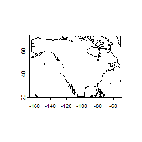

```r
plot(naMap)
```

Let’s do the same for a growing season precipitation H isoscape for North America. Notice this is a spatial raster (SpatRaster) with two layers, the mean prediction and a standard error of the prediction. The layers are from [waterisotopes.org](https://wateriso.utah.edu/waterisotopes/), and their resolution has been reduced to speed up processing in these examples. Full-resolution isoscapes of several different types can be downloaded using the `getIsoscapes` function (refer to the help page for details).

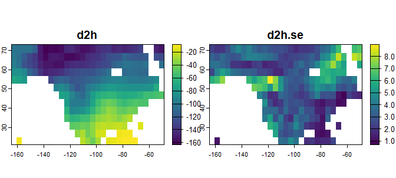

```r
plot(d2h_lrNA)
```

The package includes a database of H and O isotope data for known origin samples (`knownOrig.rda`), which consists of three features (`sites`, `samples`, and `sources`). Let’s load it and have a look. First we’ll get the names of the data fields available in the tables.

```r
names(knownOrig$sites)
```

```
## [1] "Site_ID"    "Site_name"  "State"      "Country"    "Site_comme"
```

```r
names(knownOrig$samples)
```

```
##  [1] "Sample_ID"      "Sample_ID_orig" "Site_ID"        "Dataset_ID"
##  [5] "Taxon"          "Group"          "Source_quality" "Age_class"
##  [9] "Material_type"  "Matrix"         "d2H"            "d2H.sd"
## [13] "d18O"           "d18O.sd"
```

```r
names(knownOrig$sources)
```

```
##  [1] "Dataset_ID"              "Dataset_name"
##  [3] "Citation"                "Sampling_method"
##  [5] "Sample_powdered"         "Lipid_extraction"
##  [7] "Lipid_extraction_method" "Exchange"
##  [9] "Exchange_method"         "Exchange_T"
## [11] "H_cal"                   "O_cal"
## [13] "Std_powdered"            "Drying"
## [15] "Analysis_method"         "Analysis_type"
## [17] "Source_comments"
```

The `sites` feature is a spatial object that records the geographic location of all sites from which samples are available.

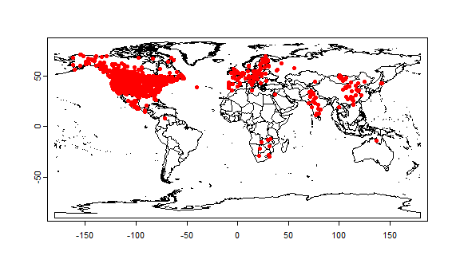

```r
plot(wrld_simpl)
points(knownOrig$sites, col = "red")
```

Now lets look at a list of species names available.

```r
unique(knownOrig$samples$Taxon)
```

```
##  [1] "Setophaga ruticilla"         "Turdus migratorius"
##  [3] "Setophaga coronata auduboni" "Poecile atricapillus"
##  [5] "Thryomanes bewickii"         "Thryothorus ludovicianus"
##  [7] "Spizella passerina"          "Geothlypis trichas"
##  [9] "Setophaga pensylvanica"      "Baeolophus bicolor"
## [11] "Vermivora chrysoptera"       "Catharus guttatus"
## [13] "Setophaga citrina"           "Geothlypis formosa"
## [15] "Geothlypis tolmiei"          "Oreothlypis ruficapilla"
## [17] "Cardinalis cardinalis"       "Oreothlypis celata"
## [19] "Junco hyemalis oregonus"     "Seiurus aurocapilla"
## [21] "Vireo olivaceus"             "Melospiza melodia"
## [23] "Catharus ustulatus"          "Catharus fuscescens"
## [25] "Vireo griseus"               "Cardellina pusilla"
## [27] "Hylocichla mustelina"        "Icteria virens"
## [29] "Setophaga petechia"          "Melozone aberti"
```

[output cut: 30 more lines]

Load H isotope data for North American Loggerhead Shrike from the package database.

```r
Ll_d = subOrigData(taxon = "Lanius ludovicianus", mask = naMap)
```

```
## 524 samples are found from 427 sites
```

```
## 524 samples from 427 sites in the transformed dataset
```

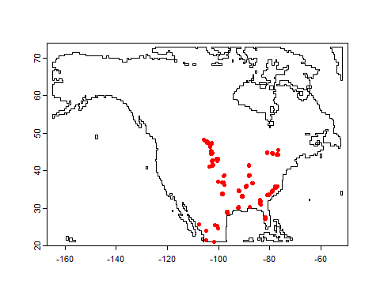

By default, the `subOrigData` function transforms all data to a common reference scale (defined by the standard materials and assigned, calibrated values for those; by default VSMOW-SLAP) using data from co-analysis of different laboratory standards (see [Magozzi et al., 2021](https://doi.org/10.1111/2041-210X.13556)). The calibrations used are documented in the function’s return object.

```r
Ll_d$chains
```

```
## [[1]]
## [1] "OldEC.1_H_1" "EC_H_7"      "EC_H_9"      "VSMOW_H"
```

Information on these calibrations is contained in the `stds.rda` data file.

Transformation is important when blending data from different labs or papers because different reference scales have been used to calibrate published data and these calibrations are not always comparable. In this case all the data come from one paper:

```r
Ll_d$sources[,1:3]
```

```
##    Dataset_ID            Dataset_name
## 18         21 Chabot et al. 2012 Plos
##                                                                                                                                                                                                                                Citation
## 18 Chabot AA, Hobson KA, Van Wilgenburg SL, McQuat GJ, Lougheed SC. 2012. Advances in linking wintering migrant birds to their breeding-ground origins using combined analyses of genetic and stable isotope markers. Plos One 7:e43627
```

If we didn’t want to transform the data, and instead wished to use the reference scale from the original publication, we can specify that in our call to `subOrigData`. Keep in mind that any subsequent analyses using these data will be based on this calibration scale: for example, if you wish to assign samples of unknown origin, the values for those samples should be reported on the same scale.

```r
Ll_d = subOrigData(taxon = "Lanius ludovicianus", mask = naMap, ref_scale = NULL)
```

```
## 524 samples are found from 427 sites
```

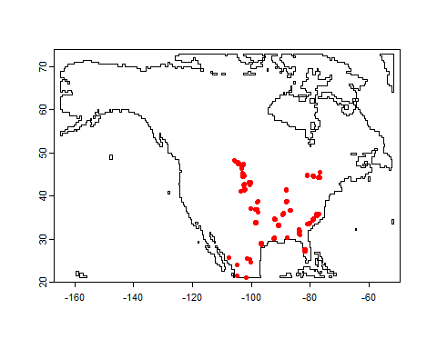

```r
Ll_d$sources$H_cal
```

```
## [1] "OldEC.1_H_1"
```

For a real application you would want to explore the database to find measurements that are appropriate to your study system (same or similar taxon, geographic region, measurement approach, etc.) or collect and import known-origin data that are specific to your system.

# Single-isoscape Analysis

We need to start by assessing how the environmental (precipitation) isoscape values correlate with the sample values. `calRaster` fits a linear model relating the precipitation isoscape values to sample values, and applies it to produce a calibrated, sample-type specific isoscape.

```r
d2h_Ll = calRaster(known = Ll_d, isoscape = d2h_lrNA, mask = naMap)
```

```
##
##
## ---------------------------------------
##         ------------------------------------------
## rescale function uses linear regression model,
##         the summary of this model is:
## -------------------------------------------
##         --------------------------------------
##
## Call:
## lm(formula = tissue.iso ~ isoscape.iso[, 1], weights = tissue.iso.wt)
##
## Residuals:
##      Min       1Q   Median       3Q      Max
## -149.640  -16.474    0.743   19.946  107.625
##
## Coefficients:
##                   Estimate Std. Error t value Pr(>|t|)
## (Intercept)        2.20058    1.81952   1.209    0.227
## isoscape.iso[, 1]  1.12628    0.04019  28.026   <2e-16 ***
## ---
## Signif. codes:  0 '***' 0.001 '**' 0.01 '*' 0.05 '.' 0.1 ' ' 1
##
## Residual standard error: 32.41 on 522 degrees of freedom
## Multiple R-squared:  0.6007, Adjusted R-squared:    0.6
## F-statistic: 785.4 on 1 and 522 DF,  p-value: < 2.2e-16
```

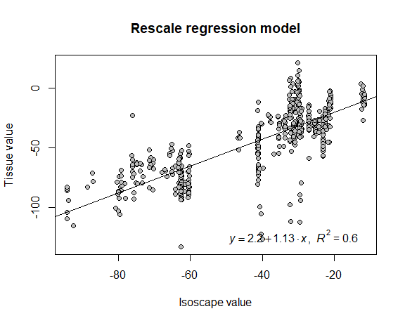

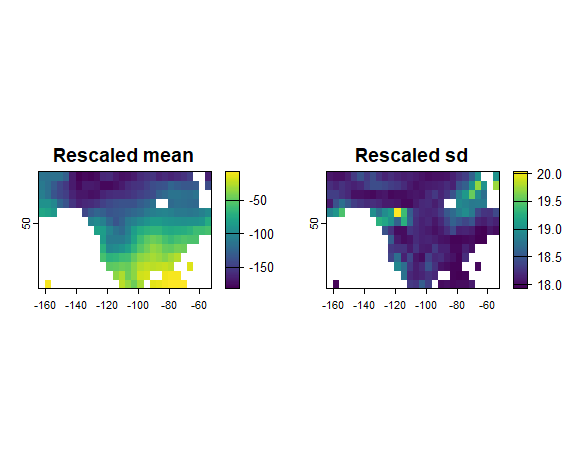

Let’s create some hypothetical samples to use in demonstrating how we can evaluate the probability that the samples originated from different parts of the isoscape. The isotope values are drawn from a random distribution with a standard deviation of 8 per mil, which is a pretty reasonable variance for conspecific residents at a single location. We’ll also add made-up values for the analytical uncertainty for each sample and a column recording the calibration scale used for our measurements. If you had real measured data for your study samples you would load them here, instead.

```r
id = letters[1:5]
set.seed(123)
d2H = rnorm(5, -110, 8)
d2H.sd = runif(5, 1.5, 2.5)
d2H_cal = rep("UT_H_1", 5)
Ll_un = data.frame(id, d2H, d2H.sd, d2H_cal)
print(Ll_un)
```

```
##   id        d2H   d2H.sd d2H_cal
## 1  a -114.48381 2.456833  UT_H_1
## 2  b -111.84142 1.953334  UT_H_1
## 3  c  -97.53033 2.177571  UT_H_1
## 4  d -109.43593 2.072633  UT_H_1
## 5  e -108.96570 1.602925  UT_H_1
```

As discussed above, one issue that must be considered with any organic H or O isotope data is the reference scale used by the laboratory producing the data. The reference scale for your unknown samples should be the same as that for the known origin data used in calRaster. Remember that the scale for our known origin data `d` is *OldEC.1_H_1*. Let’s assume that our fake data were normalized to the *UT_H_1* scale. The `refTrans` function allows us to convert between the two.

```r
Ll_un = refTrans(Ll_un, ref_scale = "OldEC.1_H_1")
print(Ll_un)
```

```
## $data
##   id       d2H   d2H.sd     d2H_cal
## 1  a -127.8800 3.374984 OldEC.1_H_1
## 2  b -125.0795 2.970657 OldEC.1_H_1
## 3  c -109.6746 2.808334 OldEC.1_H_1
## 4  d -122.5874 3.016841 OldEC.1_H_1
## 5  e -121.7123 2.594943 OldEC.1_H_1
##
## $chains
## $chains[[1]]
## [1] "UT_H_1"      "UT_H_2"      "US_H_5"      "US_H_6"      "VSMOW_H"
## [6] "EC_H_9"      "EC_H_7"      "OldEC.1_H_1"
##
##
## attr(,"class")
## [1] "refTrans"
```

Notice that both the d2H values and the uncertainties have been updated to reflect the scale transformation.

Now we will produce posterior probability density maps for the unknown samples. For reference on the Bayesian inversion method see [Wunder, 2010](https://doi.org/10.1007/978-90-481-3354-3_12)

```r
Ll_prob = pdRaster(d2h_Ll, Ll_un)
```

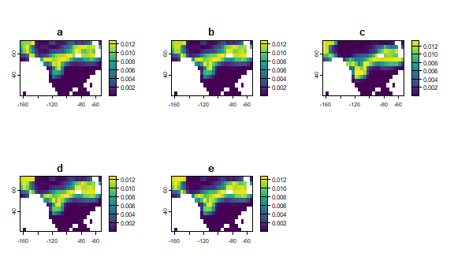

Cell values in these maps are small because each cell’s value represents the probability that this one cell, out of all of them on the map, is the actual origin of the sample. Together, all cell values on the map sum to ‘1’, reflecting the assumption that the sample originated *somewhere* in the study area. Let’s check this for sample ‘a’.

```r
global(Ll_prob[[1]], 'sum', na.rm = TRUE)
```

```
##   sum
## a   1
```

Check out the help page for `pdRaster` for additional options, including the use of informative prior probabilities.

# Multi-isoscape Analysis

We can also use multiple isoscapes to (potentially) add power to our analyses. We will start by calibrating a H isoscape for the monarch butterfly, *Danaus plexippus*.

```r
Dp_d = subOrigData(taxon = "Danaus plexippus")
```

```
## 150 samples are found from 31 sites
```

```
## 150 samples from 31 sites in the transformed dataset
```

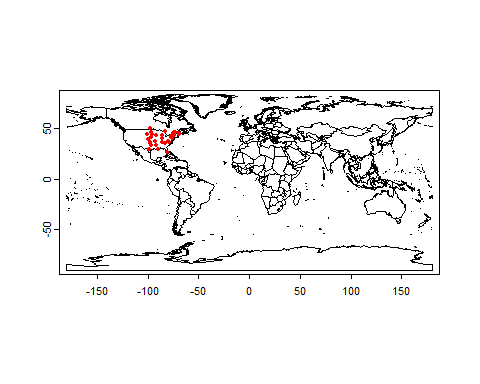

```r
d2h_Dp = calRaster(Dp_d, d2h_lrNA)
```

```
##
##
## ---------------------------------------
##         ------------------------------------------
## rescale function uses linear regression model,
##         the summary of this model is:
## -------------------------------------------
##         --------------------------------------
##
## Call:
## lm(formula = tissue.iso ~ isoscape.iso[, 1], weights = tissue.iso.wt)
##
## Weighted Residuals:
##     Min      1Q  Median      3Q     Max
## -11.030  -3.301   0.118   3.086   9.086
##
## Coefficients:
##                    Estimate Std. Error t value Pr(>|t|)
## (Intercept)       -51.98592    1.95937  -26.53   <2e-16 ***
## isoscape.iso[, 1]   0.74467    0.04055   18.37   <2e-16 ***
## ---
## Signif. codes:  0 '***' 0.001 '**' 0.01 '*' 0.05 '.' 0.1 ' ' 1
##
## Residual standard error: 4.438 on 148 degrees of freedom
## Multiple R-squared:  0.695,  Adjusted R-squared:  0.693
## F-statistic: 337.3 on 1 and 148 DF,  p-value: < 2.2e-16
```

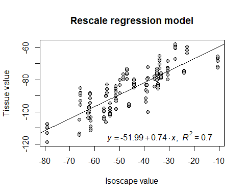

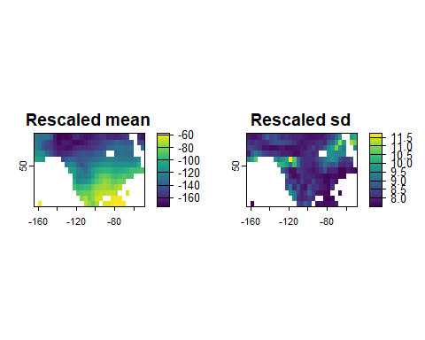

Our second isoscape represents <sup>87</sup>Sr/<sup>86</sup>Sr values across our study region, the state of Michigan. It was published by [Bataille and Bowen, 2012](https://doi.org/10.1016/j.chemgeo.2012.01.028), obtained from [waterisotopes.org](https://wateriso.utah.edu/waterisotopes/), cropped and aggregated to coarser resolution, and a rough estimate of uncertainty added.

In this case, we do not have any known-origin tissue samples to work with. However, our isoscape was developed to approximate the bioavailable Sr pool, and Sr isotopes are not strongly fractionated in food webs. Thus, our analysis will assume that the isoscape provides a good representation of the expected Sr values for our study species without calibration.

Let’s look at the Sr isoscape and compare it with our butterfly H isoscape.

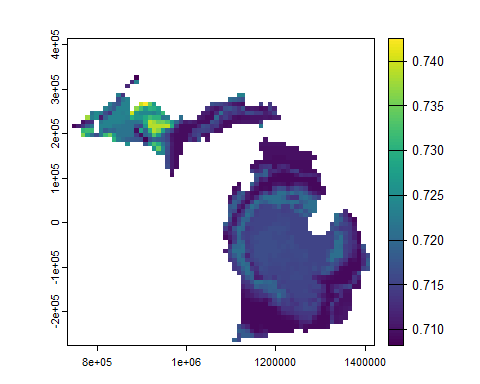

```r
plot(sr_MI$weathered.mean)
```

```r
crs(sr_MI, describe = TRUE)
```

```
##      name authority code area         extent
## 1 unknown      <NA> <NA> <NA> NA, NA, NA, NA
```

```r
crs(d2h_Dp$isoscape.rescale, describe = TRUE)
```

```
##     name authority code  area             extent
## 1 WGS 84      EPSG 4326 World -180, 180, -90, 90
```

Notice that the we have two different spatial data objects, one for Sr and one for d2H, and that they have different extents and projections. In order to conduct a multi-isotope analysis, we’ll first combine these into a single object using the `isoStack` function. In addition to combining the objects, this function resolves differences in their projection, resolution, and extent. It’s always a good idea to check that the properties of the isoStack components are consistent with your expectations.

```r
Dp_multi = isoStack(d2h_Dp, sr_MI)
lapply(Dp_multi, crs, describe = TRUE)
```

```
## [[1]]
##     name authority code  area             extent
## 1 WGS 84      EPSG 4326 World -180, 180, -90, 90
##
## [[2]]
##     name authority code  area             extent
## 1 WGS 84      EPSG 4326 World -180, 180, -90, 90
```

Now we’ll generate a couple of hypothetical unknown samples to use in our analysis. It is important that our isotopic markers appear here in the same order as in the `isoStack` object we created above.

```r
Dp_unk = data.frame("ID" = c("A", "B"), "d2H" = c(-86, -96), "Sr" = c(0.7089, 0.7375))
```

We are ready to make our probability maps. First let’s see how our posterior probabilities would look if we only used the hydrogen isotope data.

```r
Dp_pd_Honly = pdRaster(Dp_multi[[1]], Dp_unk[,-3])
```

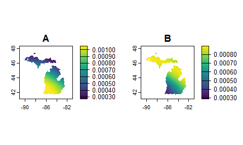

We see pretty clear distinctions between the two samples, driven by a strong SW-NE gradient in the tissue isoscape H values across the state.

What if we add the Sr information to the analysis? The syntax for running `pdRaster` is the same, but now we provide our isoStack object in place of the single isoscape. The function will use the spatial covariance of the isoscape values to approximate the error covariance for the two (or more) markers and return posterior probabilities based on the multivariate normal probability density function evaluated at each grid cell.

```r
Dp_pd_multi = pdRaster(Dp_multi, Dp_unk)
```

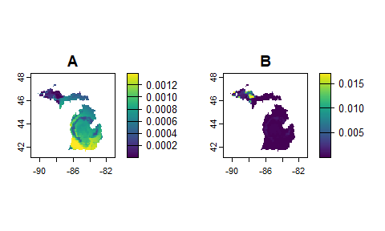

Note that the addition of Sr data greatly strengthens the geographic constraints on our hypothetical unknown samples: the difference between the highest and lowest posterior probabilities is much larger than with H only, and the pattern of high probabilities reflects the regionalization characteristic of the Sr isoscape. This is especially true for sample B, which has a fairly distinctive, high <sup>87</sup>Sr/<sup>86</sup>Sr value.

# Post-hoc Analysis

## Odds Ratio

Many of the functions in **assignR** are designed to help you analyze and draw inference from the posterior probability surfaces we’ve created above. For the following examples we’ll return to our single-isoscape, Loggerhead shrike analysis, but the tools work identically for multi-isoscape results.

The `oddsRatio` tool compares the posterior probabilities for two different locations or regions. This might be useful in answering real-world questions…for example “is this sample more likely from France or Spain?”, or “how likely is this hypothesized location relative to other possibilities?”.

Let’s compare probabilities for two spatial areas - the states of Utah and New Mexico. First we’ll extract the state boundaries from package data and plot them.

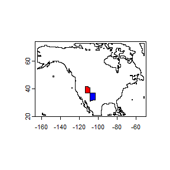

```r
s1 = states[states$STATE_ABBR == "UT",]
s2 = states[states$STATE_ABBR == "NM",]
plot(naMap)
plot(s1, col = c("red"), add = TRUE)
plot(s2, col = c("blue"), add = TRUE)
```

Now we can get the odds ratio for the two regions. The result reports the odds ratio for the regions (first relative to second) for each of the 5 unknown samples plus the ratio of the areas of the regions. If the isotope values (& prior) were completely uninformative the odds ratios would equal the ratio of areas.

```r
s12 = rbind(s1, s2)
oddsRatio(Ll_prob, s12)
```

```
## $`P1/P2 odds ratio`
##          a        b        c       d        e
## 1 135.0575 103.3676 23.81991 81.4901 74.96401
##
## $`Ratio of numbers of cells in two polygons`
## [1] 1
```

Here you can see that even though Utah is quite a bit smaller the isotopic evidence suggests it’s much more likely to be the origin of each sample. This result is consistent with what you might infer from a first-order comparison of the state map with the posterior probability maps, above.

Comparisons can also be made using points. Let’s create two points (one in each of the Plover regions) and compare their odds. This result also shows the odds ratio for each point relative to the most- and least-likely grid cells on the posterior probability map.

```r
pp1 = c(-112,40)
pp2 = c(-105,33)
pp12 = vect(rbind(pp1,pp2))
crs(pp12) = crs(naMap)
oddsRatio(Ll_prob, pp12)
```

```
## $`P1/P2 odds ratio`
##          a        b        c       d        e
## 1 135.0575 103.3676 23.81991 81.4901 74.96401
##
## $`Odds relative to the max/min pixel`
##    ratioToMax.a ratioToMax.b ratioToMax.c ratioToMax.d ratioToMax.e
## P1  0.142601991  0.189999596   0.62090197  0.242956048  0.264186459
## P2  0.001057785  0.001842557   0.02627544  0.002990584  0.003535904
##    ratioToMin.a ratioToMin.b ratioToMin.c ratioToMin.d ratioToMin.e
## P1    788227211    379309665    6786651.8    197841044    157417235
## P2      5846869      3678427     287198.7      2435256      2106891
```

The odds of the first point being the location of origin are pretty high for each sample, and much higher than for the second point.

## Distance and Direction

A common goal in movement research is to characterize the distance or direction of movement for individuals. The `wDist` tool and it’s helper methods are designed to leverage the information in the posterior probability surfaces for this purpose.

The analyses conducted in **assignR** cannot determine a single unique location of origin for a given sample, but the do give the probability that each location on the map is the location of origin. If we know the collection location for a sample, we can calculate the distance and direction between each possible location of origin and the collection site, and weighting these by their posterior probability generate a distribution (and statistics for that distribution) describing the distance and direction of travel.

Let’s do a weighted distance analysis for our first two unknown origin loggerhead shrike samples. Since these are pretend samples, we’ll pretend that the two point locations we defined above for the `oddsRatio` analysis are the locations at which these samples were collected. Here are those locations plotted with the corresponding posterior probability maps.

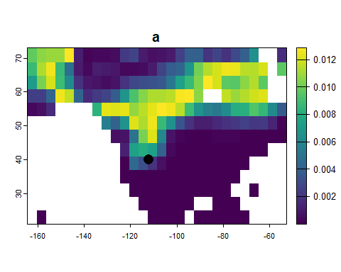

```r
# View the data
plot(Ll_prob[[1]], main = names(Ll_prob)[1])
points(pp12[1], cex = 2)
```

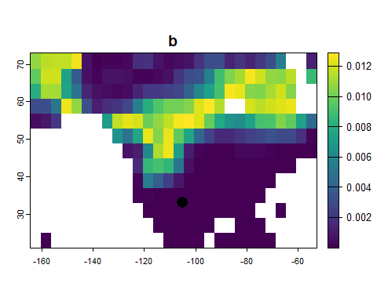

```r
plot(Ll_prob[[2]], main = names(Ll_prob)[2])
points(pp12[2], cex = 2)
```

Now let’s run the analysis and use the functions `c` and `plot` to view the summary statistics and distributions returned by `wDist`.

```r
wd = wDist(Ll_prob[[1:2]], pp12)
c(wd)[c(1,2,4,6,8,10,12,14,16)] #only showing select columns for formatting!
```

```
##   Sample_ID wMeanDist w10Dist w50Dist w90Dist wMeanBear  w10Bear   w50Bear
## 1         a   2876806 1290783 3150518 4138590 -169.8907 115.5482 -159.2225
## 2         b   3518660 2008390 3618131 4953292  178.3507 113.3519  177.4966
##     w90Bear
## 1 -105.5870
## 2 -118.4943
```

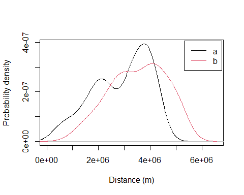

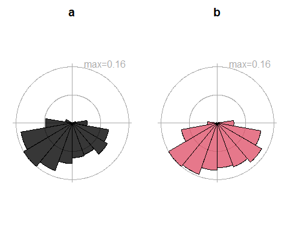

```r
plot(wd)
```

Comparing these statistics and plots with the data shows how the `wDist` metrics nicely summarize the direction and distance of movement. Both individuals almost certainly moved south from their location of origin to the collection location. Individual a’s migration may have been a little bit shorter than b’s, and in a more southwesterly direction, patterns that are dominated more by the difference in collection locations than the probability surfaces for location of origin. Also notice the multi-modal distance distribution for individual a…these can be common in `wDist` summaries so it’s a good ideal to look at the distributions themselves before choosing and interpreting summary statistics.

## Assignment

Researchers often want to classify their study area in to regions that are and are not likely to be the origin of the sample (effectively ‘assigning’ the sample to a part of the area). This requires choosing a subjective threshold to define how much of the study domain is represented in the assignment region. `qtlRaster` offers two choices.

Let’s extract 10% of the study area, giving maps that show the 10% of grid cells with the highest posterior probability for each sample.

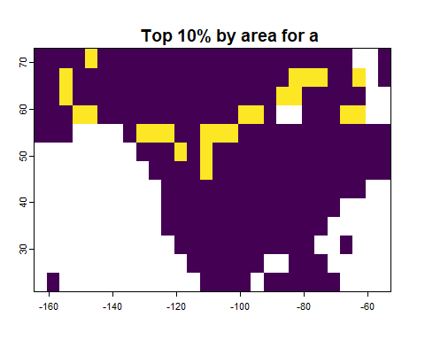

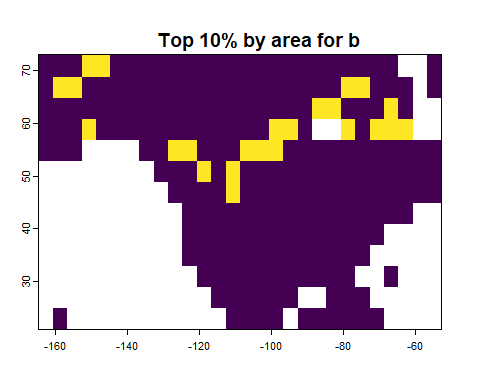

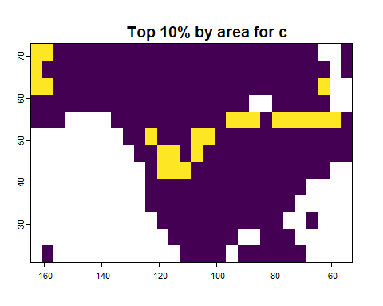

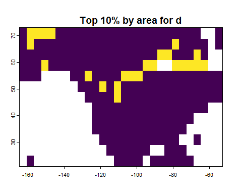

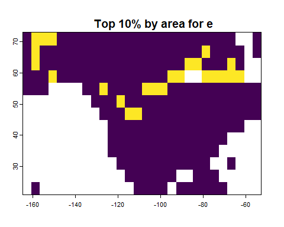

```
## class       : SpatRaster
## dimensions  : 13, 28, 5  (nrow, ncol, nlyr)
## resolution  : 3.999998, 3.999998  (x, y)
## extent      : -164.6667, -52.66672, 20.99996, 72.99993  (xmin, xmax, ymin, ymax)
## coord. ref. : lon/lat WGS 84 (EPSG:4326)
## source(s)   : memory
## varname     : d2h_lrNA
## names       :     a,     b,     c,     d,     e
## min values  : FALSE, FALSE, FALSE, FALSE, FALSE
## max values  :  TRUE,  TRUE,  TRUE,  TRUE,  TRUE
```

```r
qtlRaster(Ll_prob, threshold = 0.1)
```

Now we’ll instead extract 80% of the posterior probability density, giving maps that show the smallest region within which there is an 80% chance each sample originated.

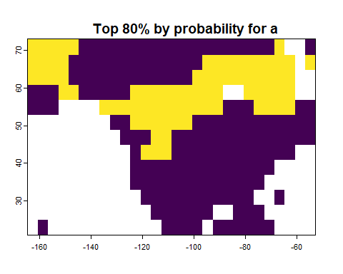

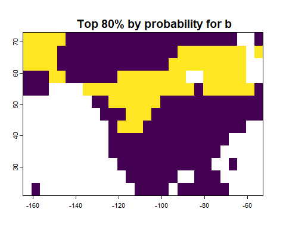

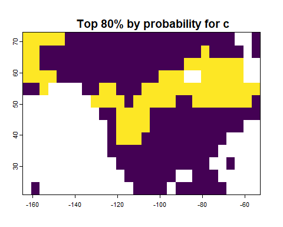

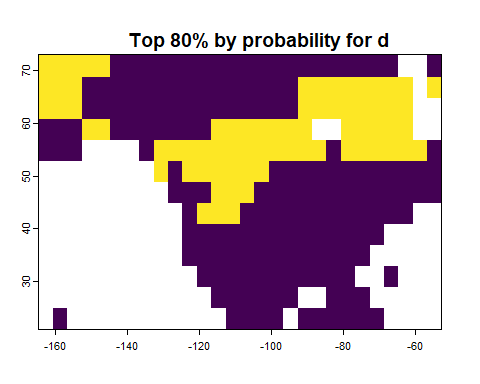

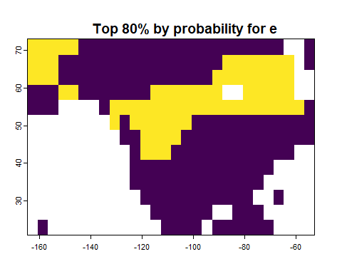

```
## class       : SpatRaster
## dimensions  : 13, 28, 5  (nrow, ncol, nlyr)
## resolution  : 3.999998, 3.999998  (x, y)
## extent      : -164.6667, -52.66672, 20.99996, 72.99993  (xmin, xmax, ymin, ymax)
## coord. ref. : lon/lat WGS 84 (EPSG:4326)
## source(s)   : memory
## varname     : d2h_lrNA
## names       :     a,     b,     c,     d,     e
## min values  : FALSE, FALSE, FALSE, FALSE, FALSE
## max values  :  TRUE,  TRUE,  TRUE,  TRUE,  TRUE
```

```r
qtlRaster(Ll_prob, threshold = 0.8, thresholdType = "prob")
```

Comparing the two results, the probability-based assignment regions are broader. This suggests that we’ll need to assign to more than 10% of the study area if we want to correctly assign 80% or more of our samples. We’ll revisit this below and see how we can chose thresholds that are as specific as possible while achieving a desired level of assignment ‘quality’.

## Summarization

Most studies involve multiple unknown samples, and often it is desirable to summarize the results from these individuals. `jointP` and `unionP` offer two options for summarizing posterior probabilities from multiple samples.

`jointP` calculates the probability that **all** samples came from each grid cell in the analysis area. Note that this summarization will only be useful if all samples are truly derived from a single population of common geographic origin.

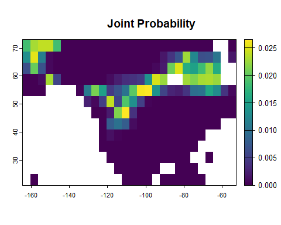

```
## class       : SpatRaster
## dimensions  : 13, 28, 1  (nrow, ncol, nlyr)
## resolution  : 3.999998, 3.999998  (x, y)
## extent      : -164.6667, -52.66672, 20.99996, 72.99993  (xmin, xmax, ymin, ymax)
## coord. ref. : lon/lat WGS 84 (EPSG:4326)
## source(s)   : memory
## varname     : d2h_lrNA
## name        : Joint_Probability
## min value   :      6.226650e-46
## max value   :      2.650864e-02
```

```r
jointP(Ll_prob)
```

`unionP` calculates the probability that **any** sample came from each grid cell in the analysis area. In this case we’ll save the output to a variable for later use.

```r
Ll_up = unionP(Ll_prob)
```

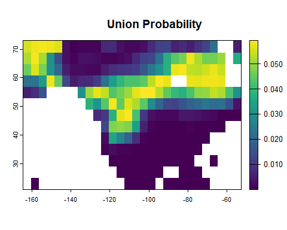

The results from `unionP` highlight a broader region, as you might expect.

Any of the other post-hoc analysis tools can be applied to the summarized results. Here we’ll use `qtlRaster` to identify the 10% of the study area that is most likely to be the origin of one or more samples.

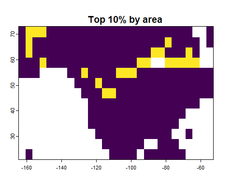

```
## class       : SpatRaster
## dimensions  : 13, 28, 1  (nrow, ncol, nlyr)
## resolution  : 3.999998, 3.999998  (x, y)
## extent      : -164.6667, -52.66672, 20.99996, 72.99993  (xmin, xmax, ymin, ymax)
## coord. ref. : lon/lat WGS 84 (EPSG:4326)
## source(s)   : memory
## name        :  lyr1
## min value   : FALSE
## max value   :  TRUE
```

```r
qtlRaster(Ll_up, threshold = 0.1)
```